# CWTS Database Data Dictionary

07/03/2025

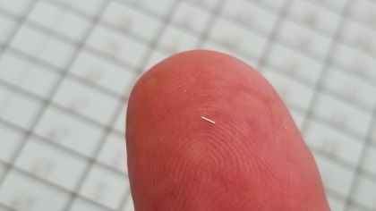

# **Database Overview**

#### Disclaimer

The Coded Wire Tag System (CWTS) database is a work in progress and is subject to change.

### Coded Wire Tag System (CWTS) Database

Coded-wire tag recovery information becomes part of the WDFW CWT Recovery Database from one of four sources: 1. The intact snout is delivered to the Tag Lab from samplers for coring, wire retrieval, and reading. 2. The wire, already dissected from a snout, is delivered to the Tag Lab. 3. Electronic tag result information is delivered to the Tag Lab or the Database Manager 4. Recovery records are created by the Database manager.

1. Collection of snouts with coded-wire tags by samplers: Field samplers and others identify fish containing wire tags in their snouts either via the presence of an adipose fin clip (method in use through the late 1990’s) or by a device (hand-held wand or stationary tunnel) that detects the magnetic tag. The snout is cut off of these fish, just behind the eyes, and the fish head is labeled, bagged, and taken to the Tag Recovery Lab in Olympia. A sample label or form accompanies the snout throughout the Tag Lab process as data is recorded into the recovery database. The wire is usually attached to the label or form; then the label is filed. This is the source of most recovery records.

The Tag Recovery Lab processing steps: Frozen snouts are partially thawed and checked for the presence of a wire via a magnetic detector (V detector). If no wire is found, the snout is re-magnetized in case the wire has lost its magnetic moment. Snouts without wire are identified as “no tags” and recorded as such. If a wire is determined to be present, a cylindrical core is extracted in the likely location of the wire. The core is systematically dissected until the wire is found. Tag wires are attached to the accompanying snout label and then read under a microscope. The code on the tag and the type of tag are recorded. Periodically, the number of cores is recorded (the number of times the dissector had to core the head in order to find the wire) for assessing the incidence of misplaced tags. The Tag Lab staffs keys the tag reading, tag type, and the collection data for the snout into an electronic data file. As the data are entered, the entry program checks for valid data and for unlikely tag readings when compared to tag release information. Invalid or unlikely data results in an interruption in the entry program so that the data entry staff can reread the tag wire or re-enter invalid data. The entered data is re-keyed in a verification process by a different person from the data entry person.

2. Wire, already read, delivered to the Tag Lab: The wire is re-read by the Tag Lab staff to validate the tag reading and assign the tag type. Any revisions are noted on the accompanying label or form. Sometimes the paper form is changed by the Tag Lab staff to fit with protocol for the fishery. The tag result information and collection information is then keyed into the recovery database. These records are also verified, as described above. Examples of fisheries where this occurs is Skagit River chinook spawning ground, Snake River sport steelhead, and Methow Hatchery spring chinook. For some WDFW hatchery recoveries, Tag Recovery Lab staff reads the snouts on-site.
3. Wire and/or electronic recovery data submitted by other projects: The electronic data is reformatted and imported into the recovery database by the Database Manager. The Tag Recovery Lab staff reads the wire to validate the initial reading and to assign the tag type if needed. The Tag Lab then verifies the data and makes any needed corrections.  
   An example of this is Lyons Ferry Hatchery Fall Chinook. Other projects include Ocean Treaty Troll by the Makah Tribe, region 3 Priest Rapids & Ringold Springs fall chinook, Mid-Upper Mainstem Columbia River FW sport, and Hanford Reach & Priest Pool spawning ground survey.
4. Recoveries added by Database Manager: These are usually records where the snout did not reach the Tag Lab, but the sampling information indicates that CWT’d snouts were detected. This is most common for spawning ground survey recoveries, hatchery rack fish released upstream, and for stream trap recoveries where the CWT’d wild fish are noted but not sacrificed. No verification is performed by the Tag Lab.

### CWTS Core Tables Schema

**What are the core tables in the CWTS database?** CWTS core data tables include expansion, recovery_group, and recovery_fish

1. expansion contains catch, sample, and expansion (derived) data and is linked to the recovery_fish table to assign expansion factors to individual fish.
2. recovery_group data describes the fishery, gear, time strata, species, and user groups for a sampling event and is linked to recovery_fish.
3. recovery_fish contains individual fish data.

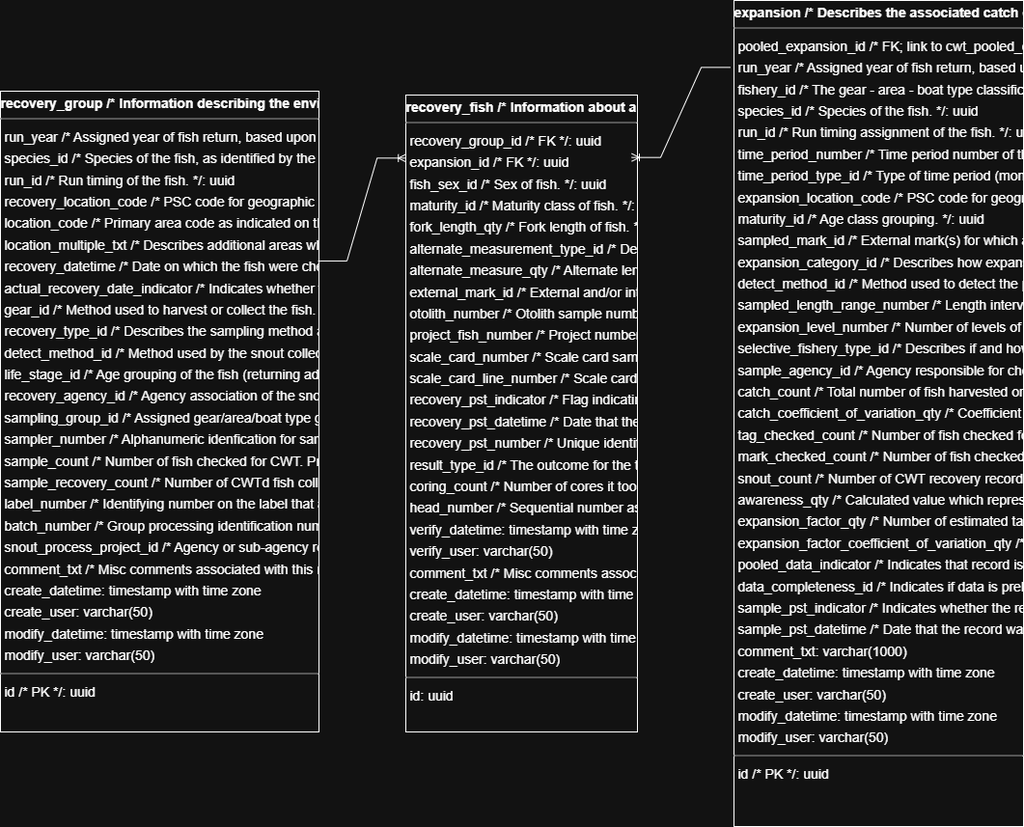

### Database statistics

**How much data is being entered in CWTS?** Counts of records in specific tables are indicated in the corresponding sections later in this document. The following plot shows trends of monthly CWT recovery data counts made since 2008.

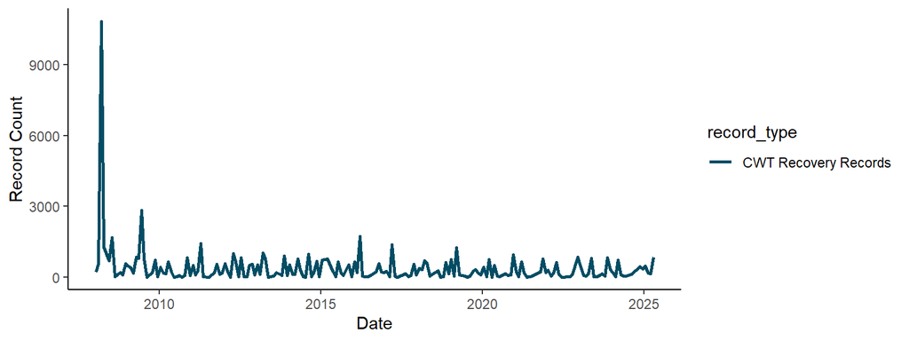

**Where are Coded Wire Tags being recovered?** The following map shows where CWTs are being recovered. This section is still under development!!!

[interactive chart not shown]

### Public Data Portal

CWTS data contained in this system is mirrored on the WDFW open data portal at https://www.data.wa.gov. The dataset can be accessed directly through the public web portal. Data is refreshed in this system nightly.

### Contact Information

For more information, please contact the CWTS data manager Gil Lensegrav at gilbert.lensegrav@dfw.wa.gov .

# **expansion**

Describes the associated catch or return, number of fish checked, and processing information used for estimating the number of coded-wire tagged fish present in fisheries and escapement.

Total Records: **155672**

| FieldName | Nullable? | DataType | Descr |
| --- | --- | --- | --- |
| id | no | uuid | PK |
| pooled_expansion_id | yes | uuid | FK; link to cwt_pooled_expansion. |
| run_year | no | integer | Assigned year of fish return, based upon the brood class. Usually the same as calendar year, except for coho and steelhead escapement. |
| fishery_id | no | uuid | The gear - area - boat type classification. |
| species_id | no | uuid | Species of the fish. |
| run_id | yes | uuid | Run timing assignment of the fish. |
| time_period_number | no | integer | Time period number of the record, based upon time period type. |
| time_period_type_id | no | uuid | Type of time period (month, week, annual, etc.) used to report the information. |
| expansion_location_code | no | character varying | PSC code for geographic location of catch, sample, and/or recoveries. |
| maturity_id | yes | uuid | Age class grouping. |
| sampled_mark_id | yes | uuid | External mark(s) for which a unique sampling treatment was applied. |
| expansion_category_id | no | uuid | Describes how expansion is applied to associated recovery. |
| detect_method_id | no | uuid | Method used to detect the presence of the wire in the fish snout, or if no CWT sampling occured, the method that would have been used for this species, fishery and run year. |
| sampled_length_range_number | yes | character varying | Length interval range specification. |
| expansion_level_number | no | integer | Number of levels of the PSC hierarchial recovery location codes to use to obtain the location code used for expansion. |
| selective_fishery_type_id | yes | uuid | Describes if and how the fishery was selective for adipose fin clipped fish. |
| sample_agency_id | no | uuid | Agency responsible for checking fish for marks and/or CWT. |
| catch_count | yes | integer | Total number of fish harvested or enumerated, as recorded in official WDFW databases |
| catch_coefficient_of_variation_qty | yes | numeric | Coefficient of variation for the Catch_Cnt value expressed as a percent. |
| tag_checked_count | yes | integer | Number of fish checked for coded-wire tag presence. May be calculated from CWT_CHECKED_TAG / CWT_CHECKED_MARK fields. |
| mark_checked_count | yes | integer | Number of fish checked for adipose fin clips. May be calculated from CWT_CHECKED_TAG / CWT_CHECKED_MARK fields. |
| snout_count | yes | integer | Number of CWT recovery records associated with this record. May be calculated from CWT_CHECKED_TAG / CWT_CHECKED_MARK fields. |
| awareness_qty | yes | numeric | Calculated value which represents the percentage of tagged snouts, caught by unsampled sport anglers, that are returned to the agency for processing. |
| expansion_factor_qty | yes | numeric | Number of estimated tagged fish represented by each recovery associated with this record (calculated). |
| expansion_factor_coefficient_of_variation_qty | yes | numeric | Expansion factor coefficent of variation. |
| pooled_data_indicator | yes | boolean | Indicates that record is linked to a pooled strata record in table CWT_POOLED_EXPANSION. |
| data_completeness_id | no | uuid | Indicates if data is preliminary or final status. |
| sample_pst_indicator | yes | boolean | Indicates whether the record should be submitted to PST coastwide data system. |
| sample_pst_datetime | yes | timestamp with time zone | Date that the record was last submitted to PST coastwide data system. |
| comment_txt | yes | character varying | NA |

### fishery_lut

The distinct geographical, gear, and fisher type combination.

| short_description | description |
| --- | --- |
| Aborig. Gillnet | Aboriginal Gillnet |
| Aborig. Mix Net | Aboriginal Mixed Net |
| Aborig. Seine | Aboriginal Seine |
| Aborig. Troll | Aboriginal Troll |
| Brdstk & Hatch | Mixed Wild Broodstock & Hatchery |
| Broodstock | Broodstock Collection |
| Coastal Gillnet | Coastal Gillnet |
| Col R Gillnet | Columbia River Gillnet |
| Col River Shad | Columbia River Shad |
| Col River Sport | Columbia River Sport |
| Comm Seine | Commercial Seine |
| Dead Fsh Survey | Dead Fish Survey |
| Escapemt: Other | Other Escapement |
| Estuary Sport | Estuary Sport |
| Fish Screens | Fish Screens |
| For.Mship Vessl | Foreign Mothership Vessels |
| For.Res. Vessel | Foreign Research Vessels |
| Frshwater Seine | Freshwater Seine |
| FshTrap -Marine | Fish Trap (Marine) |
| Fshwater Sport | Freshwater Sport |
| GNet Juv Sample | Juvenile Sampling -Gillnet (Marine) |
| Grndfsh Obs BSA | Groundfish Observer (Bering/Aleut) |
| Grndfsh Obs COW | Groundfish Observer (CA/WA/OR) |
| Grndfsh Obs GAk | Groundfish Observer (Gulf Alaska) |
| Hatchery Rack | Hatchery Rack |
| High Seas - Oth | High Seas - Other |
| Juv Smpl -Other | Juvenile Sampling - Other |
| Juvenile Smplng | Juvenile Sampling - Seine (Marine) |
| Lnd Based Salmn | Land Based Salmon |
| Misc. - Other | Miscellaneous - Other |
| Mix Net & Seine | Mixed Net & Seine |
| Multiple Gear | Multiple Gear |
| NonTreaty Troll | Non-Treaty Troll |
| NT Troll -Day | Non-Treaty Troll -Day Boat |
| NT Troll -Trip | Non-Treaty Troll -Trip Boat |
| Ocean Gillnet | Ocean Gillnet |
| Ocean Sport | Ocean Sport -Mixed Boat Types |
| Ocn Sport Jetty | Ocean Sport -Shore-based |
| Ocn Spt Charter | Ocean Sport -Charter Boat |
| Ocn Spt Private | Ocean Sport -Private Boat |
| Ocn Trl - Frzer | Ocean Troll - Freezer Boat |
| Ocn Trl -Ice Bt | Ocean Troll - Ice Boat |
| Ocn Trwl By-Cat | Ocean Trawl By-Catch |
| Other Net | Other Net |
| Other Seine | Other Seine |
| PNP Cost Recvry | PNP Cost Recovery |
| PSeine Test | Purse Seine Test |
| Seine Juv Smpl | Juvenile Sampling - Seine (Freshwater) |
| Set Lne (Sturg) | Set Line (Sturgeon) |
| Snag Sport | Special Snag Sport |
| Spawning Ground | Spawning Ground Survey |
| Sport - Other | Sport - Other |
| Squid GN By-Cat | Squid Gillnet By-Catch |
| Stream Trap | Stream Trap |
| Terminal Seine | Terminal Seine |
| Terminal Sport | Terminal Sport |
| Terminal Troll | Terminal Troll |
| Test - Other | Test Fishery - Other |
| Test Fshry Net | Test Fishery Net |
| Test Fshry Trap | Test Fishery Trap |
| Test Fshry Unkn | Test Fishery Unknown Multiple Gear |
| Treaty Troll | Treaty Troll |
| Trl Juv Sample | Juvenile Sampling - Troll (Marine) |
| Troll - Other | Troll - Other |
| Troll -All | Non-Treaty & Treaty Troll |
| Troll Test | Troll Test Fishery |
| Trty Ceremonial | Treaty Ceremonial |
| Trty Substnce | Treaty Subsistence |
| UpColR Trib Net | Freshwater Net (Upper Columbia River Tribuataries) |

### species_lut

The salmonid species assignment, various coding schemes.

| description | cwt_species_code |
| --- | --- |
| Atlantic Salmon | 9 |
| Chinook | 1 |
| Chum | 2 |
| Coho | 4 |
| Cutthroat | 8 |
| Masu | 7 |
| Pink | 3 |
| Sockeye | 5 |
| Steelhead | 6 |
| Unknown | 0 |

### run_lut

Run timing assignment, various coding schemes.

| description | cwt_run_code |
| --- | --- |
| Bright | 5 |
| Fall | 2 |
| Hybrid | 11 |
| Landlocked | 12 |
| Late Winter | 13 |
| Spring | 1 |
| Summer | 4 |
| Type N | 8 |
| Type S | 9 |
| Winter | 3 |

### time_period_type_lut

The time period system used to group counts of recoveries, catch, and sampling information.

| description | code |
| --- | --- |
| Bi-weekly | 2 |
| Calendar month | 5 |
| Daily | 9 |
| Escapement period | 1 |
| Seasonal | 8 |
| Semi-monthly | 3 |
| Statistical month | 4 |
| Statistical week (Monday-Sunday) | 6 |
| Statistical week (Sunday-Saturday) | 7 |
| Weekday | B |
| Weekend | A |

### maturity_lut

The age class of the fish.

| description | code |
| --- | --- |
| Adult | 3 |
| Immature | 1 |
| Jack | 2 |
| Mini Jack | 5 |
| Mixed | 4 |
| Not Applicable | 0 |
| Unknown | 6 |

### sampled_mark_lut

External and/or internal tags, brands, and/or fin clips applied to or identified on the fish.

| short_description | description |
| --- | --- |
| AD + Anal | Adclip + Anal |
| AD + Dye | Adipose Fin Clip + Dye |
| AD + Dye + Oto | Adipose Fin Clip + Dye + Otolith |
| AD + LftMax + RgtMax | Adclip + Left Maxillary Right Maxillary |
| AD + LP | Adipose Fin Clip + Left Pectoral Fin Clip |
| AD + LP + LftMax | Adclip + Left Pectoral Left Maxillary |
| AD + LP + RgtMax | Adclip + Left Pectoral Right Maxillary |
| AD + LV | Adipose Fin Clip + LeftVent Fin Clip |
| AD + LV + RV + LftMax | Adclip + Left Ventral Right Ventral Left Maxillary |
| AD + OtherArea | Adipose Fin Clip + CWT in Area Other Than Snout |
| AD + Oto + RghtMax | Adipose Fin Clip + Otolith + Right Maxillary |
| AD + Oto + RV | Adclip + Otolith + Right Ventral |
| AD + RP | Adipose Fin Clip + Right Pectoral Fin Clip |
| AD + RP + LftMax | Adclip + Right Pectoral Left Maxillary |
| AD + RP + RgtMax | Adclip + Right Pectoral Right Maxillary |
| AD + RV | Adipose Fin Clip + RghtVent Fin Clip |
| AD + Unkn | Adipose Fin Clip + Unknown or Unspecified Other |
| AD + VI-EI | Adipose Fin Clip + Visual Implant Elastomer Injection |
| AD Fin Clp | Adipose Fin Clip |
| AD+Caudal | Adipose Fin Clip + Caudal Fin Clip |
| AD+Caudal+ELI/LER | Adipose Fin Clip + Caudal Fin Clip+Elastomer Injection Left Eye Red |
| AD+Caudal+ELI/RER | Adipose Fin Clip + Caudal Fin Clip+Elastomer Injection Right Eye Red |
| AD+Dorsal | Adipose Fin Clip + Dorsal Fin Clip |
| AD+Dorsal+ELI/REG | Adipose Fin Clip + Dorsal Fin Clip + Elastomer Injection Right Eye Green |
| AD+EI/LEO | Adipose Fin Clip + Elastomer Injection Left Eye Orange |
| AD+EI/LEP | Adipose Fin Clip + Elastomer Injection Left Eye Pink |
| AD+EI/REP | Adipose Fin Clip + Elastomer Injection Right Eye Pink |
| AD+ELI/LEB | Adipose Fin Clip + Elastomer Injection Left Eye Blue |
| AD+ELI/LEG | Adipose Fin Clip + Elastomer Injection Left Eye Green |
| AD+ELI/LER | Adipose Fin Clip + Elastomer Injection Left Eye Red |

[output cut: 92 more lines]

### expansion_category_lut

Describes whether and how a recovery expansion is calculated or assigned.

| description | code |
| --- | --- |
| Insample recoveries or catch/sample from a sampled fishery with known catch | 1 |
| Recoveries that are selectively removed from certain in-river sampling programs | 7 |
| Sample or in-sample recoveries from a sampled fishery with unknown catch | 4 |
| Voluntary recoveries from a sampled fishery with known catch | 5 |
| Voluntary recoveries from an unsampled fishery | 3 |
| Voluntary recoveries from indirectly sampled sport fishery | 6 |
| Voluntary recoveries or catch/sample from a sampled fishery with known catch | 2 |

### detect_method_lut

The method used to identify a fish that is carrying a coded-wire tag in its snout.

| description | code |
| --- | --- |
| All Snouts Collected | A |
| Electronic | E |
| Visual | V |

### selective_fishery_type_lut

The regulations in place at the time of fish collection that allow or disallow taking a fish with an adipose fin clip.

| short_description | description |
| --- | --- |
| Adclip Only | Only adclipped fish may be kept |
| Limited Non-Adclip | Limits on number of non-adclipped fish kept |
| No Adclip Limits | No limits based on the adclipped status of fish |

### sample_agency

Reference table that lists various state, federal, local, and tribal agencies along with commonly used abbreviations.

| name | code |
| --- | --- |
| Aboriginal Fishery Strategy Program (BC) | AFSP |
| Aboriginal Fishery Strategy Program(BC) | AFSP |
| Alaska Aquaculture Inc (AK) | AAI |
| Alaska Department of Fish and Game | ADFG |
| Alaska Research Facility | ARF |
| Alaska SeaLife Center | ASLC |
| American Aquaculture Inc (AK) | AAC |
| Anadromous Inc. (OR) | ANAD |
| Armstrong Keta Inc (AK) | AKI |
| British Columbia Fish & Wildlife | BCFW |
| Burnt Hill Salmon Ranch (now OPSR) (OR) | BHSR |
| Burro Creek Farms (AK) | BURR |
| C.W. Heckard Company (OR) | HECK |
| California Department of Water Resources | CDWR |
| California Dept. of Fish and Wildlife | CDFW |
| Central Council Tlingit-Haida Indian Tribes of Alaska (AK) | THFDC |
| Ceratodus Fisheries (OR) | CERA |
| Chehalis Tribe (WA) | CHEH |
| Chickaloon Village Trade Council (AK) | CVTC |
| Clatsop Economic Development Council (OR) | CCF |
| College of Fisheries University of Washington | UW |
| Columbia River Inter-Tribal Fish Commission | CRITFC |
| Colville Indian Tribe | CCT |
| Confederated Tribes of the Umatilla Indian Reservation | CTUIR |
| Confederated Tribes of Warm Springs of Oregon (OR) | CTWSRO |
| Cook Inlet Aquaculture Association (AK) | CIAA |
| Cooperative - agency | COOP |
| Domsea Farms Inc. (OR-WA) | DOMS |
| Douglas Island Pink and Chum Inc (AK) | DIPAC |
| Douglas Public Utilities | DCPUD |

[output cut: 87 more lines]

### data_completeness_lut

Describes if the data is in a preliminary status (changeable) or considered final.

| description | code |
| --- | --- |
| Final | F |
| Preliminary | P |

# **recovery_group**

Information describing the environment in which fish having coded wire tags were collected. Based upon a single written label that accompanies one to many snouts to the Tag Recovery Lab.

Total Records: **1010393**

| FieldName | Nullable? | DataType | Descr |
| --- | --- | --- | --- |
| id | no | uuid | PK |
| run_year | no | smallint | Assigned year of fish return, based upon the brood class. Usually same as calendar year except for coho and steelhead escapement. |
| species_id | no | uuid | Species of the fish, as identified by the person collecting the snout. |
| run_id | yes | uuid | Run timing of the fish. |
| recovery_location_code | yes | character varying | PSC code for geographic area where fish was recovered. |
| location_code | yes | character varying | Primary area code as indicated on the snout label. |
| location_multiple_txt | yes | character varying | Describes additional areas where multiple area sampling occured. |
| recovery_datetime | yes | timestamp with time zone | Date on which the fish were checked for wire. |
| actual_recovery_date_indicator | yes | boolean | Indicates whether the recovery date is actual (or estimated). |
| gear_id | yes | uuid | Method used to harvest or collect the fish. |
| recovery_type_id | yes | uuid | Describes the sampling method and the sampling group that collected the snouts. |
| detect_method_id | yes | uuid | Method used by the snout collector to detect the presence of the wire in the fish snout. |
| life_stage_id | no | uuid | Age grouping of the fish (returning adult, jack, or smolt). |
| recovery_agency_id | yes | uuid | Agency association of the snout collector. |
| sampling_group_id | no | uuid | Assigned gear/area/boat type grouping. |
| sampler_number | yes | character varying | Alphanumeric idenfication for sampler who collected the snout. |
| sample_count | yes | integer | Number of fish checked for CWT. Present in some sampling groups and not in others. |
| sample_recovery_count | yes | integer | Number of CWTd fish collected. |
| label_number | yes | character varying | Identifying number on the label that accompanies one or more snouts from the collection point to the tag recovery lab. |
| batch_number | yes | character varying | Group processing identification number assigned to this label by the data entry person. |
| snout_process_project_id | yes | uuid | Agency or sub-agency responsible for coring the fish snout and reading the wire extracted. |
| comment_txt | yes | character varying | Misc comments associated with this record. |

### species_lut

The salmonid species assignment, various coding schemes.

| description | cwt_species_code |
| --- | --- |
| Atlantic Salmon | 9 |
| Chinook | 1 |
| Chum | 2 |
| Coho | 4 |
| Cutthroat | 8 |
| Masu | 7 |
| Pink | 3 |
| Sockeye | 5 |
| Steelhead | 6 |
| Unknown | 0 |

### run_lut

Run timing assignment, various coding schemes.

| description | cwt_run_code |
| --- | --- |
| Bright | 5 |
| Fall | 2 |
| Hybrid | 11 |
| Landlocked | 12 |
| Late Winter | 13 |
| Spring | 1 |
| Summer | 4 |
| Type N | 8 |
| Type S | 9 |
| Winter | 3 |

### gear_lut

The capture method or method of collection of the fish.

| short_description | description |
| --- | --- |
| BchSeine | Beach Seine |
| Brdstock | Broodstock Collection |
| Dip Net | Dip Net |
| Drift GN | Drift Gill Net |
| FW Snag | Freshwater Snag |
| FW Sport | Freshwater Sport |
| Hat Rack | Hatchery Rack |
| Hk & Ln | Hook & Line |
| Mar Spt | Marine Sport |
| Mixed GN | Mixed Gill Net |
| Net&Sein | Mixed Gillnet +Seine |
| Pnd Net Trap | Pound Net Trap |
| Ps Seine | Purse Seine |
| Reef Net | Reef Net |
| Rnd Haul | Round Haul |
| Set GN | Set Gill Net |
| Survey | Spwning Ground Survey |
| Trap | Commercial Trap |
| Trap | Stream Trap |
| Trawl | Trawl |
| Troll | Troll |
| Trty DGN | Treaty Drift Gill Net |
| Trty PS | Treaty Purse Seine |
| Trty Trl | Treaty Troll |

### recovery_type_lut

Describes circumstances about the recoveries and the collection method.

| description |
| --- |
| Incidental Sample |
| Random nonWDFW Sample |
| Random WDFW Sample |
| Select Sample |
| Test Fishery Sample |
| Unspecified |
| Voluntary Sample |

### detect_method_lut

The method used to identify a fish that is carrying a coded-wire tag in its snout.

| description |
| --- |
| All Snouts Collected |
| Electronic |
| Visual |

### life_stage_lut

The age-based grouping of the fish differentiating outgoing smolt versus matured fish.

| description |
| --- |
| Outgoing Smolt |
| Returning Adult |

### recovery_agency

Reference table that lists various state, federal, local, and tribal agencies along with commonly used abbreviations.

| code | name |
| --- | --- |
| AAC | American Aquaculture Inc (AK) |
| AAI | Alaska Aquaculture Inc (AK) |
| ADFG | Alaska Department of Fish and Game |
| AFSP | Aboriginal Fishery Strategy Program (BC) |
| AFSP | Aboriginal Fishery Strategy Program(BC) |
| AKI | Armstrong Keta Inc (AK) |
| ANAD | Anadromous Inc. (OR) |
| ARF | Alaska Research Facility |
| ASLC | Alaska SeaLife Center |
| BCFW | British Columbia Fish & Wildlife |
| BHSR | Burnt Hill Salmon Ranch (now OPSR) (OR) |
| BURR | Burro Creek Farms (AK) |
| CCF | Clatsop Economic Development Council (OR) |
| CCT | Colville Indian Tribe |
| CCTHITA | Tlingit-Haida Central Council (AK) |
| CDFO | Fisheries and Oceans Canada |
| CDFR | Fisheries and Oceans Canada - Research |
| CDFW | California Dept. of Fish and Wildlife |
| CDWR | California Department of Water Resources |
| CERA | Ceratodus Fisheries (OR) |
| CHEH | Chehalis Tribe (WA) |
| CIAA | Cook Inlet Aquaculture Association (AK) |
| COOP | Cooperative - agency |
| CRITFC | Columbia River Inter-Tribal Fish Commission |
| CTUIR | Confederated Tribes of the Umatilla Indian Reservation |
| CTWSRO | Confederated Tribes of Warm Springs of Oregon (OR) |
| CVTC | Chickaloon Village Trade Council (AK) |
| DCPUD | Douglas Public Utilities |
| DIPAC | Douglas Island Pink and Chum Inc (AK) |
| DOMS | Domsea Farms Inc. (OR-WA) |

[output cut: 87 more lines]

### snout_process_project_lut

The agency and project that processed the snouts determined to have wire.

| description |
| --- |
| Chelan PUD |
| Hatchery Staff (Recov Hatch) |
| Hoh Tribe (WA) |
| Idaho Fish and Game |
| La Conner Office |
| Lummi Tribe |
| Makah Tribe |
| Muckleshoot Tribe |
| NMFS Lab |
| Nooksack Tribe |
| Oregon Fish & Wildlife |
| Puget Sound Energy |
| Quileute Tribe (WA) |
| Skagit River System Cooperative |
| Squaxin Island Tribe (WA) |
| Stillaguamish Tribe |
| Suquamish Tribe |
| Swinomish Tribe |
| Tulalip Tribe |
| University of WA Staff |
| Upper Skagit Tribe |
| US Fish and Wildlife Service |
| WDFW Otolith Lab |
| WDFW Region 1 Staff |
| WDFW Region 2 Staff |
| WDFW Region 3 Staff |
| WDFW Region 4 Staff |
| WDFW Region 5 Staff |
| WDFW Snake R Lab Staff |
| WDFW Tag Lab |
| Yakama Tribe |

# **recovery_fish**

Information about an individual fish that was determined in the field to have a coded-wire tag in its snout. Includes information about the processing of that fish snout.

Total Records: **3788482**

| FieldName | Nullable? | DataType | Descr |
| --- | --- | --- | --- |
| id | no | uuid | NA |
| recovery_group_id | no | uuid | FK |
| expansion_id | yes | uuid | FK |
| fish_sex_id | yes | uuid | Sex of fish. |
| maturity_id | yes | uuid | Maturity class of fish. |
| fork_length_qty | yes | smallint | Fork length of fish. |
| alternate_measurement_type_id | yes | uuid | Describes the type of alternative measurement used for the fish that carries the CWT. |
| alternate_measure_qty | yes | smallint | Alternate length of fish. |
| external_mark_id | yes | uuid | External and/or internal tags, brands, and/or fin clips applied to or identified on the fish. |
| otolith_number | yes | character varying | Otolith sample number of fish. |
| project_fish_number | yes | character varying | Project number of fish. Sample groups typically use this to link to their own internal data system. |
| scale_card_number | yes | character varying | Scale card sample number of fish. |
| scale_card_line_number | yes | smallint | Scale card line sample number of fish. |
| recovery_pst_indicator | yes | boolean | Flag indicating the record is to be reported to coastwide PST data system, RMIS. |
| recovery_pst_datetime | yes | timestamp with time zone | Date that the record was last submitted to the coastwide PST data system, RMIS. |
| recovery_pst_number | yes | integer | Unique identification number assigned to this snout upon initial submission to RMIS. |
| result_type_id | no | uuid | The outcome for the tag wire in the processing of the snout. |
| coring_count | yes | smallint | Number of cores it took to find the cwt in the snout as recorded by the Taglab staff. |
| head_number | no | smallint | Sequential number assigned to snout when snouts are bagged during collection under one label. |
| verify_datetime | yes | timestamp with time zone | NA |
| verify_user | yes | character varying | NA |
| comment_txt | yes | character varying | Misc comments associated with this record. |

### fish_sex_lut

Sex of the fish.

| description |
| --- |
| Female |
| Male |
| Not Applicable |
| Sex ID attempted but not determined |

### maturity_lut

The age class of the fish.

| description |
| --- |
| Adult |
| Immature |
| Jack |
| Mini Jack |
| Mixed |
| Not Applicable |
| Unknown |

### alternate_measurement_type_lut

Lookup table that describes the type of alternative measurement used for the fish that carries the CWT.

| description |
| --- |
| Eye-operculum length (mm) |
| POH Postorbital-to-fork length |
| POH Postorbital-to-hypural plate length (cm) |
| Round weight (grams) |
| Round weight (lb) |

### external_mark_lut

External and/or internal tags, brands, and/or fin clips applied to or identified on the fish.

| short_description | description | code |
| --- | --- | --- |
| AD + Anal | Adclip + Anal | 5140 |
| AD + Dye | Adipose Fin Clip + Dye | 5450 |
| AD + Dye + Oto | Adipose Fin Clip + Dye + Otolith | 5451 |
| AD + LftMax + RgtMax | Adclip + Left Maxillary Right Maxillary | 5111 |
| AD + LP | Adipose Fin Clip + Left Pectoral Fin Clip | 5090 |
| AD + LP + LftMax | Adclip + Left Pectoral Left Maxillary | 5091 |
| AD + LP + RgtMax | Adclip + Left Pectoral Right Maxillary | 5092 |
| AD + LV | Adipose Fin Clip + LeftVent Fin Clip | 5001 |
| AD + LV + RV + LftMax | Adclip + Left Ventral Right Ventral Left Maxillary | 5054 |
| AD + OtherArea | Adipose Fin Clip + CWT in Area Other Than Snout | 5600 |
| AD + Oto + RghtMax | Adipose Fin Clip + Otolith + Right Maxillary | 5520 |
| AD + Oto + RV | Adclip + Otolith + Right Ventral | 5502 |
| AD + RP | Adipose Fin Clip + Right Pectoral Fin Clip | 5100 |
| AD + RP + LftMax | Adclip + Right Pectoral Left Maxillary | 5101 |
| AD + RP + RgtMax | Adclip + Right Pectoral Right Maxillary | 5102 |
| AD + RV | Adipose Fin Clip + RghtVent Fin Clip | 5002 |
| AD + Unkn | Adipose Fin Clip + Unknown or Unspecified Other | 5009 |
| AD + VI-EI | Adipose Fin Clip + Visual Implant Elastomer Injection | 5201 |
| AD Fin Clp | Adipose Fin Clip | 5000 |
| AD+Caudal | Adipose Fin Clip + Caudal Fin Clip | 5150 |
| AD+Caudal+ELI/LER | Adipose Fin Clip + Caudal Fin Clip+Elastomer Injection Left Eye Red | 5151 |
| AD+Caudal+ELI/RER | Adipose Fin Clip + Caudal Fin Clip+Elastomer Injection Right Eye Red | 5152 |
| AD+Dorsal | Adipose Fin Clip + Dorsal Fin Clip | 5130 |
| AD+Dorsal+ELI/REG | Adipose Fin Clip + Dorsal Fin Clip + Elastomer Injection Right Eye Green | 5132 |
| AD+EI/LEO | Adipose Fin Clip + Elastomer Injection Left Eye Orange | 5209 |
| AD+EI/LEP | Adipose Fin Clip + Elastomer Injection Left Eye Pink | 5218 |
| AD+EI/REP | Adipose Fin Clip + Elastomer Injection Right Eye Pink | 5219 |
| AD+ELI/LEB | Adipose Fin Clip + Elastomer Injection Left Eye Blue | 5203 |
| AD+ELI/LEG | Adipose Fin Clip + Elastomer Injection Left Eye Green | 5207 |
| AD+ELI/LER | Adipose Fin Clip + Elastomer Injection Left Eye Red | 5205 |

[output cut: 92 more lines]

### result_type_lut

Lists possible outcomes for the tag wire in the processing a snout identified in the field as having a wire.

| short_description | description |
| --- | --- |
| Blank Wire Tag | Tag is blank wire or agency-only wire |
| Decoded Tag | Tag was decoded with no discrepancies |
| Lost Tag | Tag was lost in lab process before reading |
| No Snout | Snout identified as CWT but not processed |
| No Tag | No tag wire was found in the snout |
| Tag Discrepancy | Recovery data incompatible with release data |
| Unreadable Tag | Complete code on the tag wire is unreadable |